# Graphs in R using ggplot2: Line Plots

⇦ Back

# 1 One Line in a Plot

To plot a line graph in ggplot2, you need:

- A data frame
- A `ggplot()` object
- A `geom_line()` object with a defined aesthetic mapping (`aes()`)

Here’s an example:

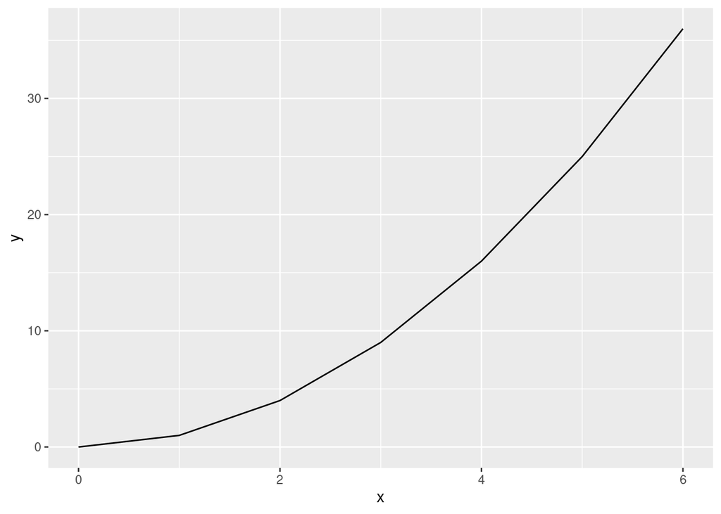

```r
library(ggplot2)

df <- data.frame(
    x = c(0, 1, 2, 3, 4, 5, 6),
    y = c(0, 1, 4, 9, 16, 25, 36)
)

p <- ggplot()
p <- p + geom_line(data = df, aes(x = x, y = y))
print(p)
```

In the above example, the y-values were simply the x-values squared, so we could have achieved the same thing with an *equation* as opposed to explicit values:

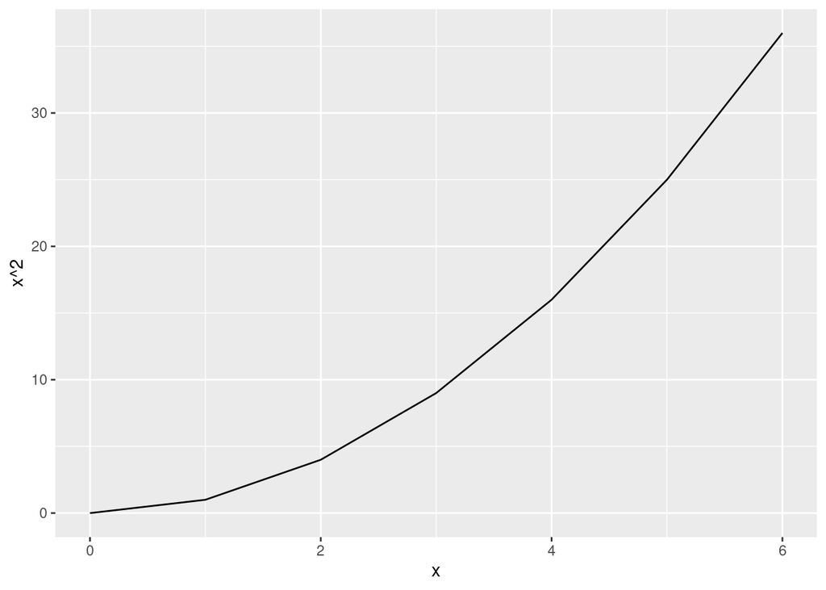

```r
df <- data.frame(
    x = c(0, 1, 2, 3, 4, 5, 6)
)

p <- ggplot()
p <- p + geom_line(data = df, aes(x = x, y = x**2))
print(p)
```

# 2 Multiple Lines in a Plot

If you want to plot additional lines on the same set of axes, add more `geom_line()` objects:

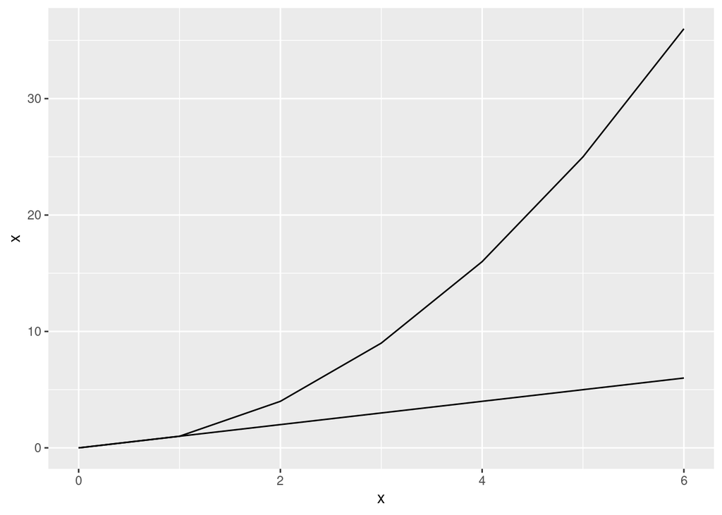

```r
df <- data.frame(
    x = c(0, 1, 2, 3, 4, 5, 6)
)

p <- ggplot()
# Add a straight line
p <- p + geom_line(data = df, aes(x = x, y = x))
# Add a parabola
p <- p + geom_line(data = df, aes(x = x, y = x**2))
print(p)
```

# 3 Axis Labels

To change the title and labels, create `ggtitle()`, `ylab()` and `xlab()` objects:

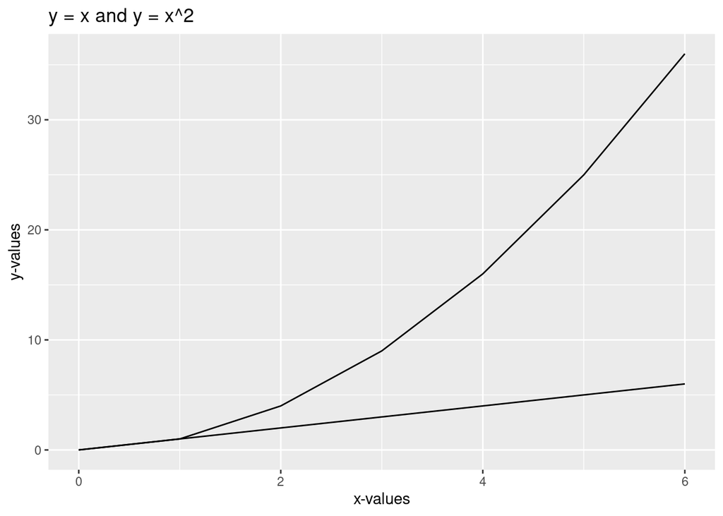

```r
df <- data.frame(
    x = c(0, 1, 2, 3, 4, 5, 6)
)

p <- ggplot()
p <- p + geom_line(data = df, aes(x = x, y = x))
p <- p + geom_line(data = df, aes(x = x, y = x**2))
p <- p + ggtitle("y = x and y = x^2")
p <- p + ylab("y-values")
p <- p + xlab("x-values")
print(p)
```

Of course, having “x^2” instead of “x²” in the title doesn’t look great. To improve this text formatting we have three options, each with their own pros and cons:

- Copy-and-paste glyphs in directly
- Use Unicode
- Use Latex

Here are examples of each option:

## 3.1 Glyphs in Labels

This is the simplest option: find the symbols you want (eg by Googling them) and copy-paste them into your code:

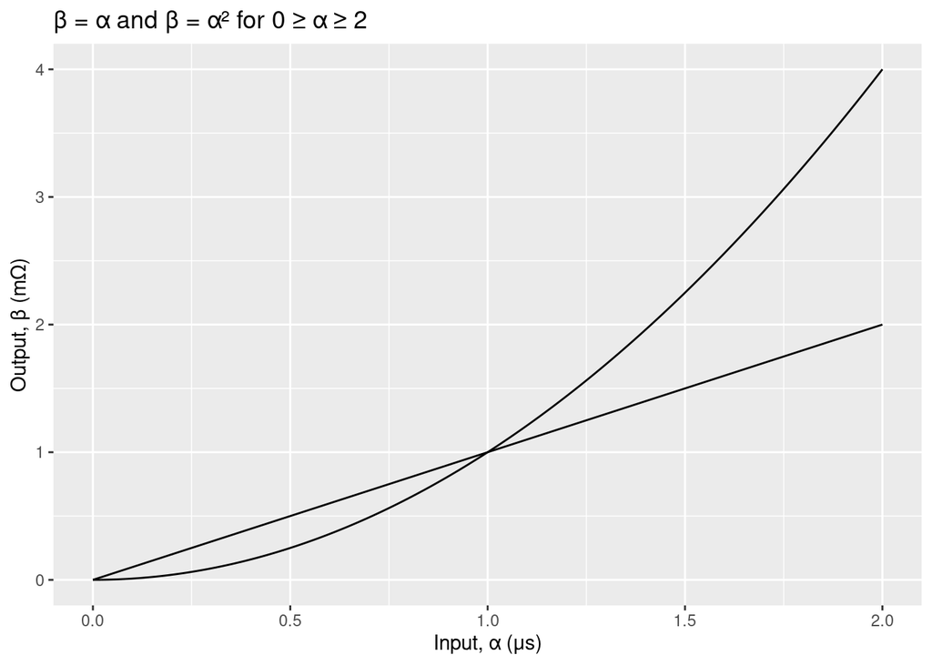

```r
df <- data.frame(x = seq(0, 2, 0.01))

p <- ggplot()
p <- p + geom_line(data = df, aes(x = x, y = x))
p <- p + geom_line(data = df, aes(x = x, y = x**2))
p <- p + ggtitle("β = α and β = α² for 0 ≥ α ≥ 2")
p <- p + ylab("Output, β (mΩ)")
p <- p + xlab("Input, α (μs)")
print(p)
```

## 3.2 Unicode in Labels

A slightly more complicated option is to look up the Unicode codes for the symbols and use those prepended by a " to let R know you want to interpret it as Unicode:

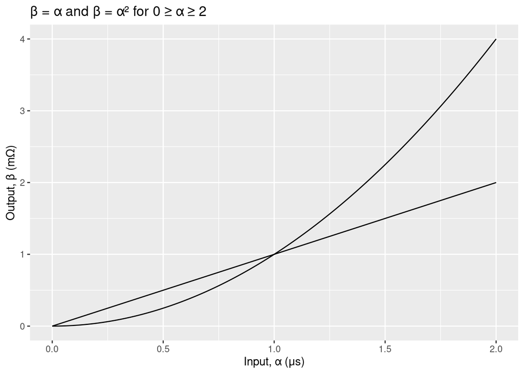

```r
df <- data.frame(x = seq(0, 2, 0.01))

p <- ggplot()
p <- p + geom_line(data = df, aes(x = x, y = x))
p <- p + geom_line(data = df, aes(x = x, y = x**2))
p <- p + ggtitle("\U03B2 = \U03B1 and \U03B2 = \U03B1\U00B2 for 0 \U2265 \U03B1 \U2265 2")
p <- p + ylab("Output, \U03B2 (m\U03A9)")
p <- p + xlab("Input, \U03B1 (\U03BCs)")
print(p)
```

## 3.3 Latex in Labels

By using the `latex2exp` package, you can use the full power of Latex to generate proper-looking labels. Note, however, that backslashes have a special meaning in R and you need to *escape* this by using a second backslash (an escaping backslash) in order to allow the first backslash be interpreted as such by Latex:

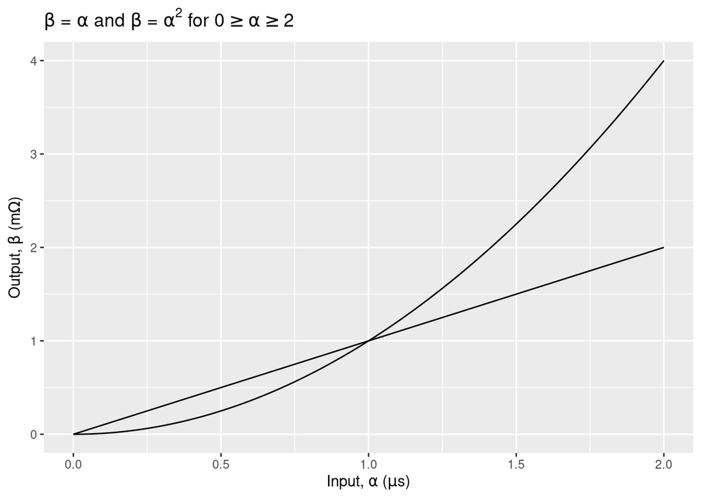

```r
library(latex2exp)

df <- data.frame(x = seq(0, 2, 0.01))

p <- ggplot()
p <- p + geom_line(data = df, aes(x = x, y = x))
p <- p + geom_line(data = df, aes(x = x, y = x**2))
p <- p + ggtitle(TeX("\\beta = \\alpha and \\beta = \\alpha$^2$ for 0\\geq\\alpha\\geq{}2"))
p <- p + ylab(TeX("Output, \\beta (m\\Omega)"))
p <- p + xlab(TeX("Input, \\alpha (\\mu{}s)"))
print(p)
```

# 4 Colours and Legend

Colours and legends are added automatically by ggplot2:

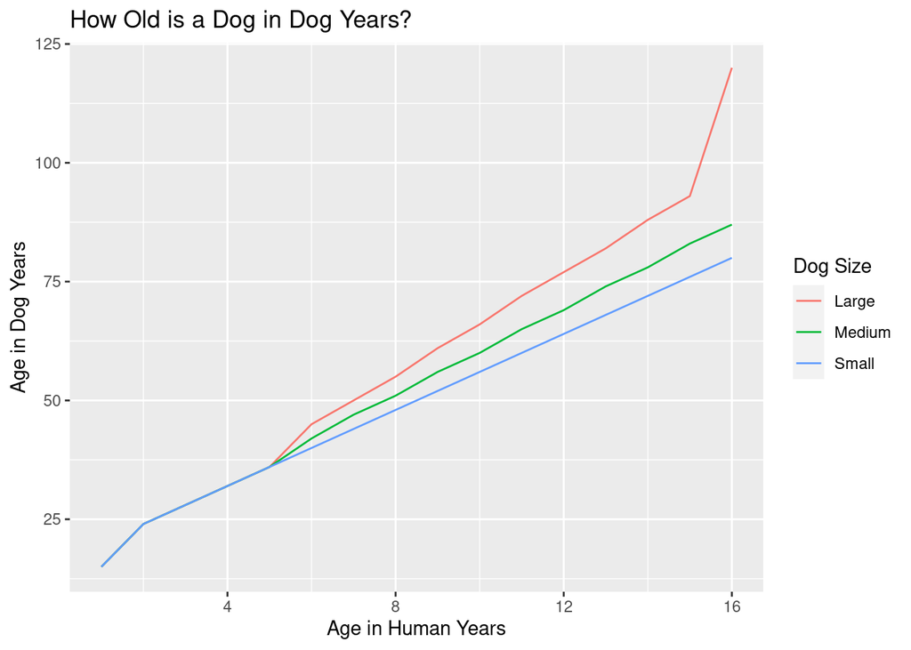

```r
df <- data.frame(
    human_age = c(1:16, 1:16, 1:16),
    dog_age = c(
        15, 24, 28, 32, 36, 45, 50, 55, 61, 66, 72, 77, 82, 88, 93, 120,
        15, 24, 28, 32, 36, 42, 47, 51, 56, 60, 65, 69, 74, 78, 83, 87,
        15, 24, 28, 32, 36, 40, 44, 48, 52, 56, 60, 64, 68, 72, 76, 80
    ),
    dog_size = c(rep("Large", 16), rep("Medium", 16), rep("Small", 16))
)

p <- ggplot(
    df, aes(x = human_age, y = dog_age, group = dog_size, col = dog_size)
)
p <- p + geom_line()
p <- p + ggtitle("How Old is a Dog in Dog Years?")
p <- p + ylab("Age in Dog Years")
p <- p + xlab("Age in Human Years")
p <- p + labs(colour = "Dog Size")
print(p)
```

FYI, the above plot comes from [this](https://pets.webmd.com/dogs/how-to-calculate-your-dogs-age) page.

## 4.1 Edit the Default Colours

If you don’t like the colours ggplot2 chooses for you, you can change them with the `scale_color_manual()` function:

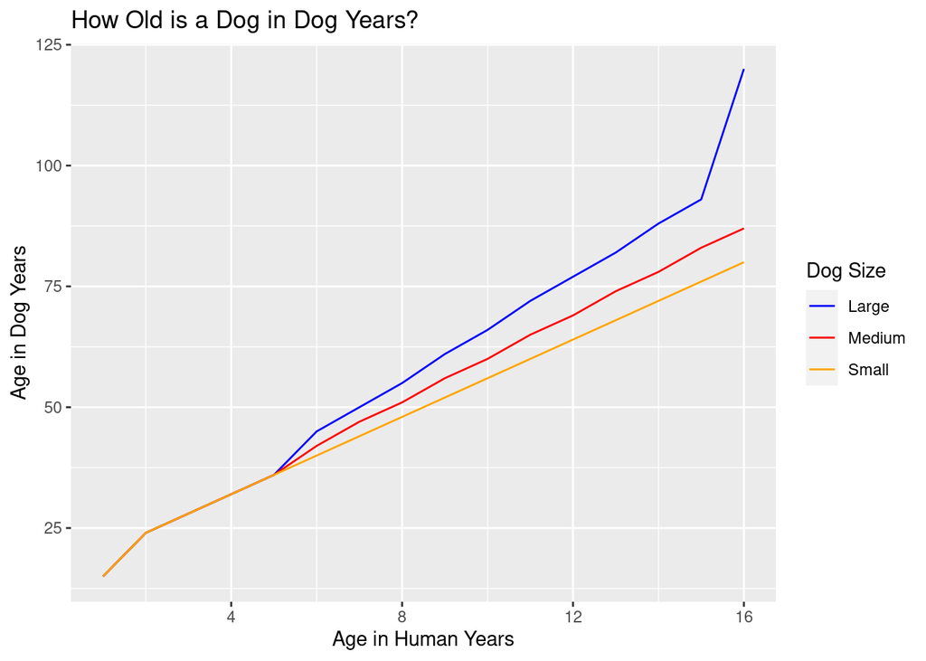

```r
p <- ggplot(
    df, aes(x = human_age, y = dog_age, group = dog_size, col = dog_size)
)
p <- p + geom_line()
p <- p + ggtitle("How Old is a Dog in Dog Years?")
p <- p + ylab("Age in Dog Years")
p <- p + xlab("Age in Human Years")
p <- p + labs(colour = "Dog Size")
p <- p + scale_color_manual(values = c("blue", "red", "orange"))
print(p)
```

# 5 Line Sizes

The thicknesses of the lines can be changed with the `scale_size_manual()` function:

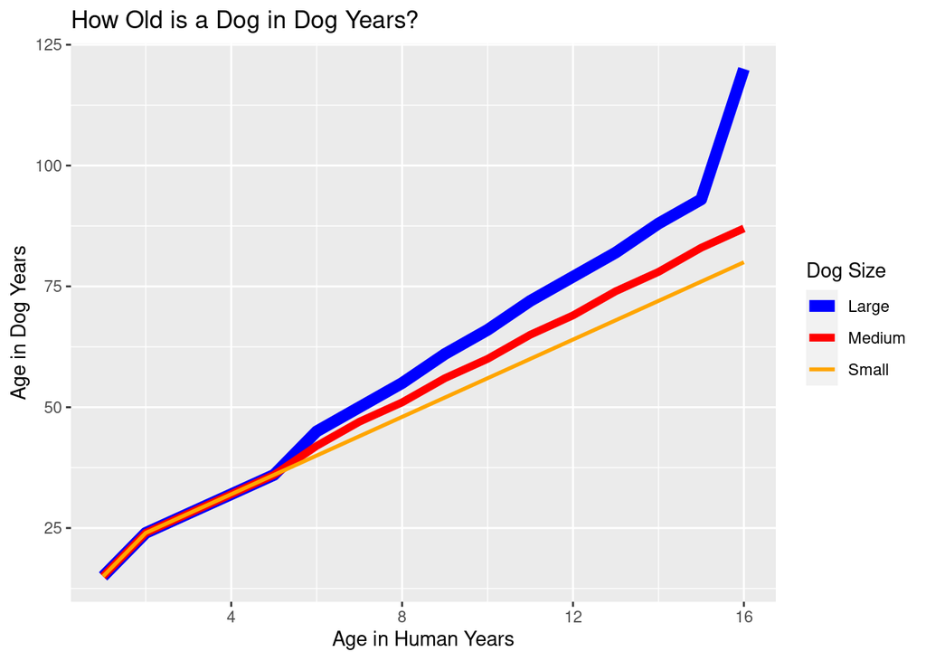

```r
p <- ggplot(
    df, aes(
        x = human_age, y = dog_age,
        group = dog_size, colour = dog_size, size = dog_size
    )
)
p <- p + geom_line()
p <- p + ggtitle("How Old is a Dog in Dog Years?")
p <- p + ylab("Age in Dog Years")
p <- p + xlab("Age in Human Years")
p <- p + labs(colour = "Dog Size", size = "Dog Size")
p <- p + scale_color_manual(values = c("blue", "red", "orange"))
p <- p + scale_size_manual(values = c(3, 2, 1))
print(p)
```

# 6 Line Types

The style of the lines can be changed with the `scale_linetype_manual()` function:

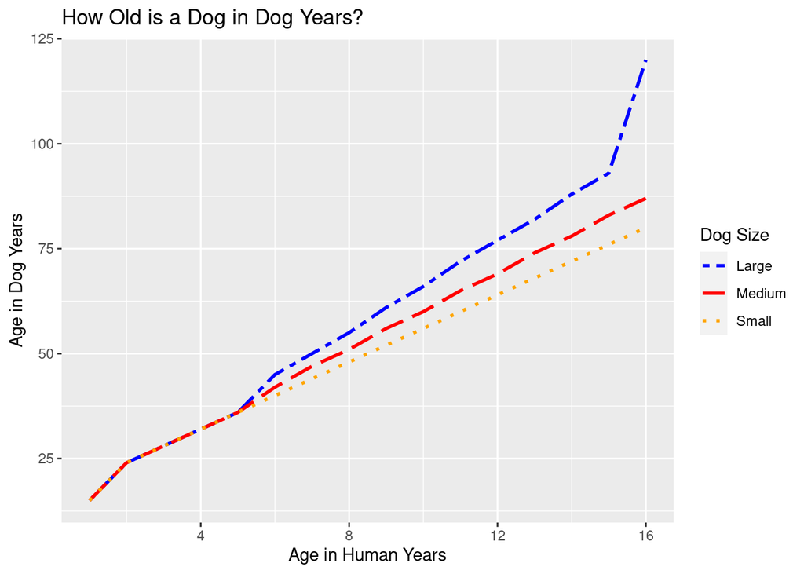

```r
p <- ggplot(
    df, aes(
        x = human_age, y = dog_age,
        group = dog_size, colour = dog_size,
        size = dog_size, linetype = dog_size
    )
)
p <- p + geom_line()
p <- p + ggtitle("How Old is a Dog in Dog Years?")
p <- p + ylab("Age in Dog Years")
p <- p + xlab("Age in Human Years")
p <- p + labs(colour = "Dog Size", size = "Dog Size", linetype = "Dog Size")
p <- p + scale_color_manual(values = c("blue", "red", "orange"))
p <- p + scale_size_manual(values = c(1, 1, 1))
p <- p + scale_linetype_manual(values = c("twodash", "longdash", "dotted"))
print(p)
```

# 7 Editing Axes and Gridlines

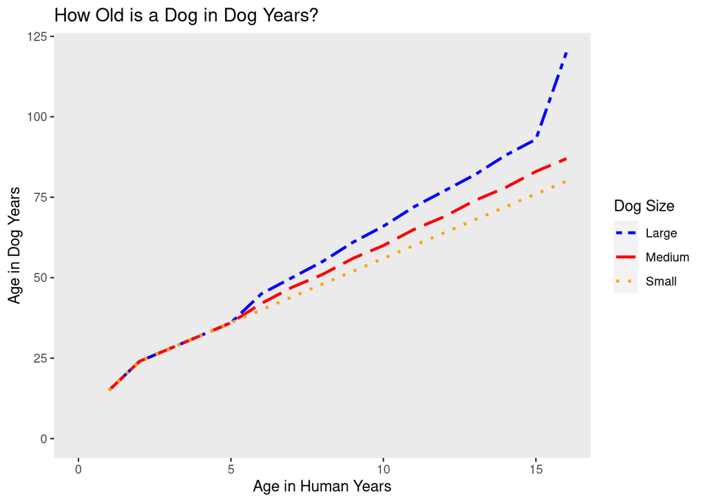

```r
p <- ggplot(
    df, aes(
        x = human_age, y = dog_age,
        group = dog_size, colour = dog_size,
        size = dog_size, linetype = dog_size
    )
)
p <- p + geom_line()
p <- p + ggtitle("How Old is a Dog in Dog Years?")
p <- p + ylab("Age in Dog Years")
p <- p + xlab("Age in Human Years")
p <- p + labs(colour = "Dog Size", size = "Dog Size", linetype = "Dog Size")
p <- p + scale_color_manual(values = c("blue", "red", "orange"))
p <- p + scale_size_manual(values = c(1, 1, 1))
p <- p + scale_linetype_manual(values = c("twodash", "longdash", "dotted"))
p <- p + theme(panel.grid.major = element_blank())
p <- p + theme(panel.grid.minor = element_blank())
p <- p + scale_y_continuous(limits = c(0, 120))
p <- p + scale_x_continuous(limits = c(0, 16))
print(p)
```

# 8 Multiple Data Sets

For this example, the raw data will be imported from a CSV file:

```r
# Import raw data
df <- read.csv(
    "https://github.com/rowannicholls/rowannicholls.github.io/blob/master/R/graphs/ggplot2/Points.csv?raw=true",
    check.names = FALSE
)
```

This CSV contains the number of log points for each team in the English Premier League for each match week of the 2018-19 season:

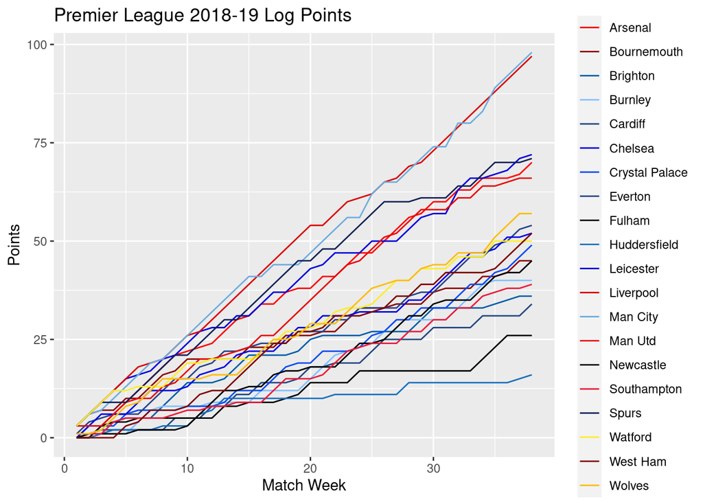

```r
p <- ggplot(df, aes(x = matchweek, y = points, group = team, col = team))
p <- p + geom_line()
p <- p + ggtitle("Premier League 2018-19 Log Points")
p <- p + ylab("Points")
p <- p + xlab("Match Week")
p <- p + labs(colour = "")
p <- p + scale_color_manual(
    values = c(
        "#ff0000", "#8b0304", "#005daa", "#80bfff", "#224781", "#0000dd",
        "#0a4af5", "#274488", "#000000", "#176fc0", "#0101e8", "#dd0000",
        "#6caddf", "#e80909", "#000000", "#ed1a3b", "#132257", "#fbee23",
        "#7f0000", "#fdbc02"
    )
)
print(p)
```

# 9 Error Bars

For this example, use the pre-installed ‘ToothGrowth’ data set. This has data from a study on the effect of vitamin C on tooth growth in guinea pigs. Here’s what the head of the data frame looks like:

```r
head(ToothGrowth)
```

```
##    len supp dose
## 1  4.2   VC  0.5
## 2 11.5   VC  0.5
## 3  7.3   VC  0.5
## 4  5.8   VC  0.5
## 5  6.4   VC  0.5
## 6 10.0   VC  0.5
```

…and here is the data plotted with its associated error bars:

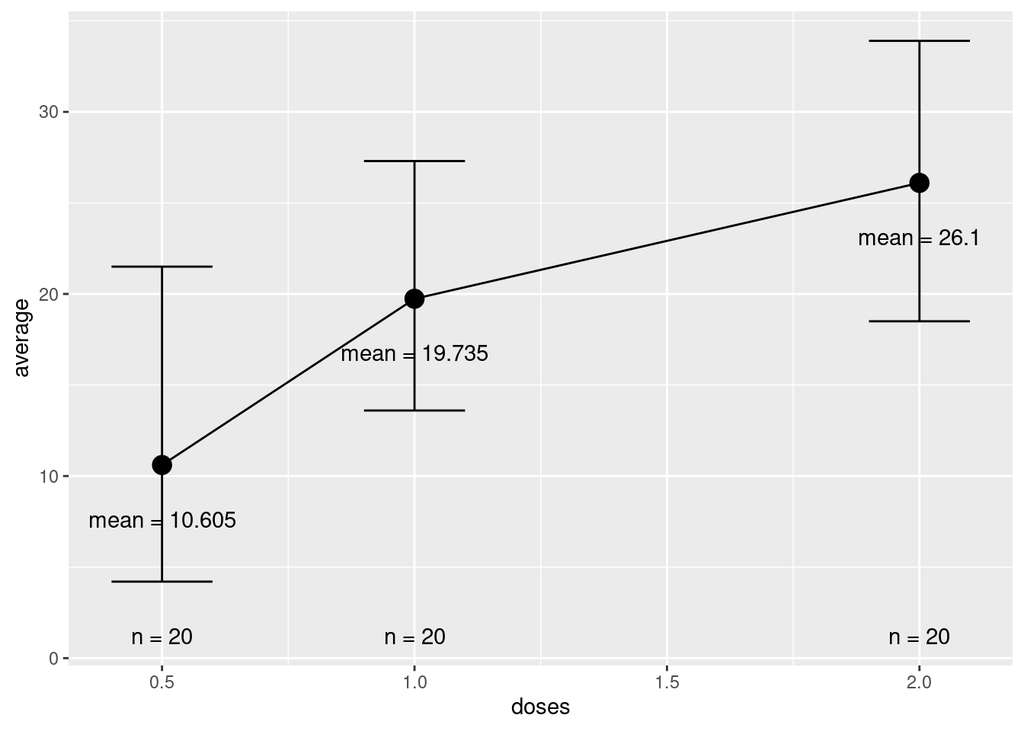

```r
df <- ToothGrowth

# Initialise vector to store maximums for each group
upper <- vector()
# Initialise vector to store minimums for each group
lower <- vector()
# Initialise vector to store averages for each group
average <- vector()
# Initialise vector to store sample sizes for each group
n <- vector()
# Analyse each dosage group
doses <- unique(df$dose)
for (dosage in doses) {
    sub <- subset(df, dose == dosage)
    upper <- c(upper, max(sub$len))
    lower <- c(lower, min(sub$len))
    average <- c(average, mean(sub$len))
    n <- c(n, length(sub$len))
}
# Get values of error bars
ytop <- max(upper)
ybottom <- min(lower)
yrange <- ytop - ybottom
df <- data.frame(doses, average, upper, lower)

# Plot
p <- ggplot(df, aes(x = doses, y = average))
p <- p + geom_point(size = 4)
p <- p + geom_line()
p <- p + geom_errorbar(aes(ymin = lower, ymax = upper), width=0.2)
p <- p + annotate(
    'text', x = doses, y = average - 0.1 * yrange,
    label = paste('mean =', average)
)
p <- p + annotate(
    'text', x = doses, y = ybottom - 0.1 * yrange, label = paste('n =', n)
)
# Add more space at the bottom in order to fit the annotations
p <- p + ylim(ybottom - 0.1 * yrange, ytop)

print(p)
```

## 9.1 Automatic Methods

A similar graph can be plotted with help from the `ggpubr` package. This approach can be useful for certain plots but can make it more difficult to control its look.

```r
library(ggpubr)

ggline(
    ToothGrowth, x = "dose", y = "len", add = c("mean_ci"), color = "supp",
    palette = "jco"
)
```

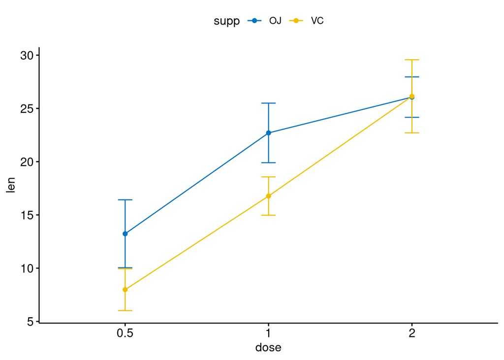

# 10 Save Plot

Finally, save your plot to your computer as an image using one of the following (depending on what format you want the image to be in):

- `png("File Name.png")`
- `pdf("File Name.pdf")`
- `ggsave("File Name.png")`

If you use one of the first two, it must come *before* you start plotting the graph (ie before you call `ggplot()`). If you use the last one (`ggsave()`) it must come *after* you’ve plotted the graph.

⇦ Back